# Sta141A Homework 2

Diana Rueda

4/21/2020

1. Generate a single simple random sample of length n <- 50 from the binomial distribution with the parameters k <- 10, p <- 0.4 (1 point).

```r
n <- 50
k <- 10
p <- 0.4
binom_sample <- rbinom(n,k,p)
```

The generated binomial single sample is:

```
##  [1] 3 5 3 4 3 7 4 2 4 6 4 3 3 4 4 2 2 3 5 4 8 5 3 4 7 3 1 5 3 6 3 2 2 3 3 1 6 7
## [39] 5 4 1 3 1 3 5 4 3 5 6 7
```

2. Write a function that takes a sample as its input and returns the estimates of k and p given above (3 points).

```r
# the function
estimate_k_p <- function(sample){
  x_bar <- mean(sample)
  var <- sum((sample - x_bar) ** 2)
  k_hat <- (x_bar ** 2) / (x_bar - ((1/length(sample)) * var))
  p_hat <- x_bar / k_hat
  c(k_hat, p_hat)
}
k_p_sample <- data.frame(estimate_k_p(binom_sample))
rownames(k_p_sample) <- c("k_estimate", "p_estimate")
```

Test run of the function to estimate k and p:

```
##            estimate_k_p.binom_sample.
## k_estimate                  15.449918
## p_estimate                   0.251134
```

3. Generate N <- 1000 samples of size n <- 50 (as in the first question) and calculate N <- 1000 estimates of k and N <- 1000 estimates of p

```r
samples_1 <- replicate(1000, rbinom(n,k,p)) #generates samples
k_p_1 <- apply(samples_1, 2, estimate_k_p) #calculates estimates
rownames(k_p_1) <- c("k-est", "p-est")
k_p_1[,1:5]  #verify
```

```
##            [,1]      [,2]       [,3]       [,4]      [,5]
## k-est 8.2589382 9.0227416 13.9541284 12.6625310 7.4283941
## p-est 0.5593939 0.4588406  0.2794872  0.2985185 0.4657803
```

4. Repeat Question 3 when n <- 100 and when n <- 250 (2 points).

```r
# n=100
n2 <- 100
samples_2 <- replicate(1000, rbinom(n2,k,p))
k_p_2 <- apply(samples_2, 2, estimate_k_p)
rownames(k_p_2) <- c("k-est", "p-est")
k_p_2[,1:5] #verify
```

```
##            [,1]       [,2]      [,3]       [,4]      [,5]
## k-est 7.0250391 15.6565495 10.573953 17.8471200 9.6619916
## p-est 0.5722388  0.2529293  0.395311  0.2274877 0.4295181
```

```r
#n=250
n3 <- 250
samples_3 <- replicate(1000, rbinom(n3,k,p))
k_p_3 <- apply(samples_3, 2, estimate_k_p)
rownames(k_p_3) <- c("k-est", "p-est")
k_p_3[,1:5] #verify
```

```
##             [,1]       [,2]       [,3]       [,4]      [,5]
## k-est 11.0751516 11.7815330 10.0199098 13.2108848 13.129565
## p-est  0.3626135  0.3452861  0.3996044  0.3121668  0.312577
```

5. Estimate the bias and the mean squared error (MSE) of k̂ and the bias and the MSE of p̂ for each sample size (n <- 50, n <- 100 and n <- 250). Do the estimators seem to overestimate or underestimate the parameters? How do the bias and the MSE change when the sample size increases? (4 points).

```r
library("Metrics")
#create k and p vectors of actual values
k_vector <- matrix(k, nrow = 1000)
p_vector <- matrix(p, nrow = 1000)
# MSE and BIAS of K for n=50 N= 1000
mse_k1 <- mse(k_vector, k_p_1[1,])
bias_k1 <- mean(k_p_1[1,]) - k
# p
mse_p1 <- mse(p_vector, k_p_1[2,])
bias_p1 <- mean(k_p_1[2,]) - p
```

The bias and the MSE of K and p for the sample size n = 50:

```
##   parameters         MSE       bias
## 1          k 33.47409305 0.80808345
## 2          p  0.01382401 0.01147983
```

```r
# k for n=100 N=1000
mse_k2 <- mse(k_vector, k_p_2[1,])
bias_k2 <- mean(k_p_2[1,]) - k
#p
mse_p2 <- mse(p_vector, k_p_2[2,])
bias_p2 <- mean(k_p_2[2,]) - p
```

The bias and the MSE of K and p for the sample size n = 100:

```
##   parameters         MSE        bias
## 1          k 6.766759868 0.371977775
## 2          p 0.006890439 0.004430803
```

```r
#k for n=250 N=1000
mse_k3 <- mse(k_vector, k_p_3[1,])
bias_k3 <- mean(k_p_3[1,]) - k
#p
mse_p3 <- mse(p_vector, k_p_3[2,])
bias_p3 <- mean(k_p_3[2,]) - p
```

The bias and the MSE of K and p for the sample size n = 250:

```
##   parameters         MSE        bias
## 1          k 1.611841974 0.070425716
## 2          p 0.002373026 0.003285196
```

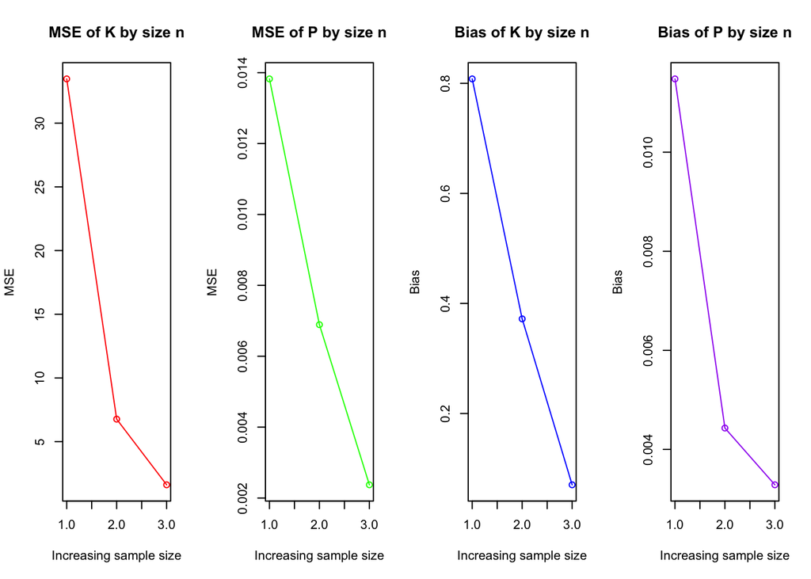

```r
mse_k <- c(mse_k1, mse_k2, mse_k3)
mse_p <- c(mse_p1, mse_p2, mse_p3)
bias_k <- c(bias_k1, bias_k2, bias_k3)
bias_p <- c(bias_p1, bias_p2, bias_p3)

par(mfrow = c(1,4))
plot(mse_k, type = "o", col = "red", main = "MSE of K by size n", ylab = "MSE", xlab = "Increasing sample size")
plot(mse_p, type = "o", col = "green", main = "MSE of P by size n", ylab = "MSE", xlab = "Increasing sample size")
plot(bias_k, type = "o", col = "blue", main = "Bias of K by size n", ylab = "Bias", xlab = "Increasing sample size")
plot(bias_p, type = "o", col = "purple", main = "Bias of P by size n", ylab = "Bias", xlab = "Increasing sample size")
```

The estimators seem to overestimate the parameter and the MSE and bias decrease as the sample size increases.

6. 1. Make a single plot using ggplot2 that contains three box plots of the estimates of the parameter k when n <- 50, n <- 100, n <- 250 (the first from the left box plot has to describe the estimates when n <- 50, the second from the left box plot has to describe the estimates when n <- 100 and the third from the left box plot has to describe the estimates n <- 250). Include the true value of the parameter as a horizontal line (geom_hline() and use the argument color) and label the plot appropriately

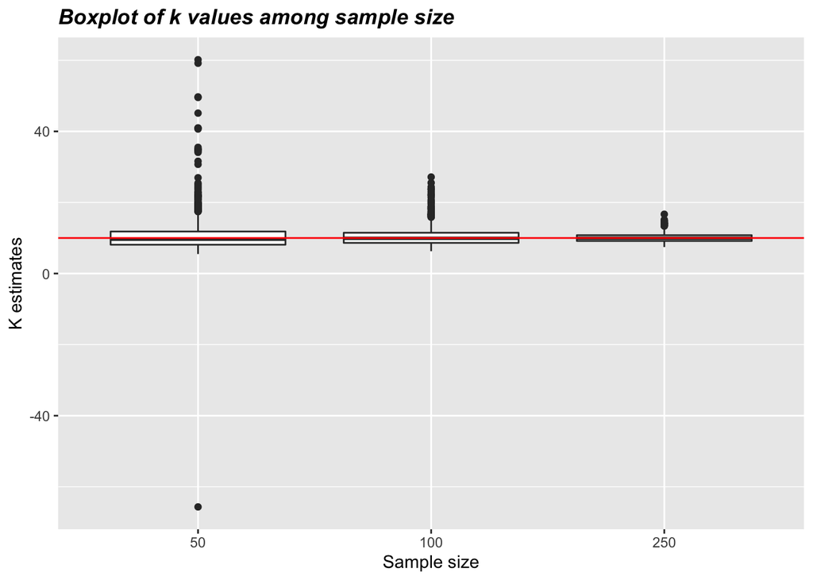

```r
library("ggplot2")
n_values <- c(rep(50,1000), rep(100, 1000), rep(250, 1000))
k_data <- data.frame(as.factor(n_values), c(k_p_1[1,],k_p_2[1,], k_p_3[1,]))
names(k_data) <- c("Samples_size_n", "K_estimate")
ggplot(data = k_data) + geom_boxplot(mapping = aes(x = Samples_size_n, y = K_estimate)) + geom_hline(yintercept = k, color = "red") + labs(x = "Sample size", y = "K estimates") + ggtitle("Boxplot of k values among sample size") + theme(plot.title = element_text(face = "bold.italic"))
```

2. k̂ can obtain values that are far away from the true value of the parameter when the sample size is small and the box plots might not be particularly informative in such a situation. Remove the estimates from the plot that are outside of the interval [0,50] so that the box plots are more informative (4 points).

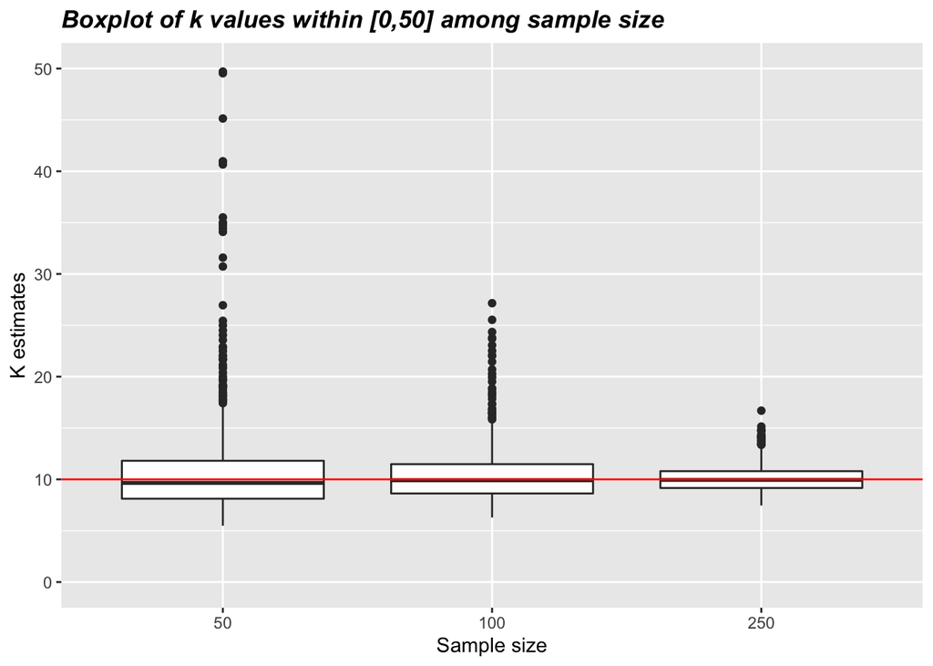

```r
ggplot(data = k_data) + geom_boxplot(mapping = aes(x = Samples_size_n, y = K_estimate)) + geom_hline(yintercept = k, color = "red") + ylim(0,50) + labs(x = "Sample size", y = "K estimates") + ggtitle("Boxplot of k values within [0,50] among sample size") + theme(plot.title = element_text(face = "bold.italic"))
```

3. Make the same plot with three box plots for the estimates of the parameter p (b part does not apply here)

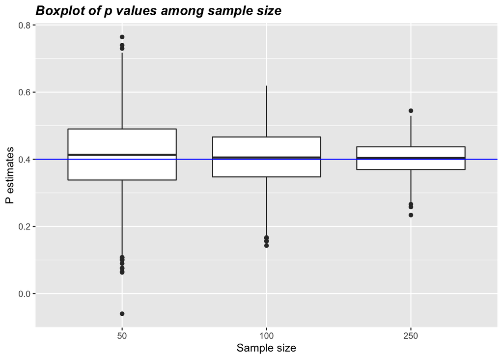

```r
p_data <- data.frame(as.factor(n_values), c(k_p_1[2,],k_p_2[2,], k_p_3[2,]))
names(p_data) <- c("Sample_size_n", "P_estimate")
ggplot(data = p_data) + geom_boxplot(mapping = aes(x = Sample_size_n, y = P_estimate)) + geom_hline(yintercept = p, color = "blue") +  labs(x = "Sample size", y = "P estimates") + ggtitle("Boxplot of p values among sample size") + theme(plot.title = element_text(face = "bold.italic"))
```

4. Describe how both of these plots change when the sample size increases (2 points).  
   As the sample size increases both estimates k and p become more accurate which means they contain less outliers and their mean is closer to the actual value of k and p of this distribution. In the same manner these plots show the area of major incidence of values narrowing as n increases.